# Water Quality Time Series Analysis

Brandon Bagley

Data for surface water was downloaded from the [USGS Water Data For the Nation](https://waterdata.usgs.gov/nwis) website for a site in Tennessee that had multiple measurements for at least a year. The data is used here to simulate a year of readings from another source to try and identify treands and predict a randomly assigned variable. The randomly assigned variable could represent a filter change, or maintenance which in the data is named `random`. The random variable was assigned to remain 0 for 95% of the timespan of the data which ranged from 2015-12-08 to 2018-03-12, and score a 1 or 2 for only 5% of the timespan.

The variables measured at the USGS site #03434870 from the river station were:

- Temperature (Celsius)  
  `temp_c_av`
- Specific Conductance (Ms per cm at 25C)  
  `SpC_ms_av`
- pH (Field)  
  `pH_av`
- Dissolved Oxygen (Mg/L)  
  `DO_mgl_av`
- Random (Simulating rare occurance event)  
  `random`

## Data exploration

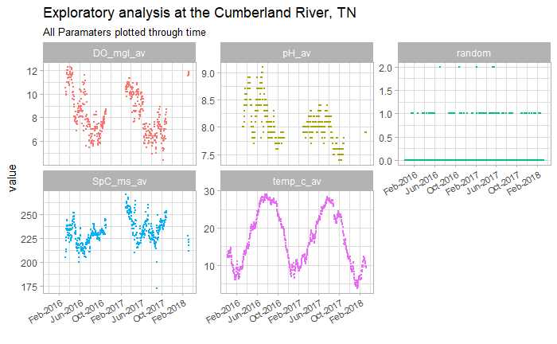

## LDA to classify the data into 3 groups (0, 1, 2) based on random, if needed

# Models

## First Steps

1. Scale the data
2. identify correlation among scaled results
3. Determine training/test/validation datasets via sampling techinques
- Could be based on a single “pump” vs all other pumps or percentage split, also resampling(bootstrap)
4. build model
5. Interogate results and if possible the residuals
- Identify Accuracy, but also ROC curves (AUC)
6. Re-evaluate model
7. Model validation via CV, OOB, Resampling techinques

## Models

### Logistic Regression to determine function of random from inputs

### Support Vector Machine to identify linear or using a kernel- non-linear function to distinguish between 0 & 1 assuming that 2 is within 1

### Neural Network to determine random variable with learning based on the probability of classes (0,1,2)

### Boosted Random FOrest to train the model on outliers whcih is the rare instances of 1 or 2 random

```r
wat_scaled <- as.data.frame(scale(wat_cumb[,3:8], center = wat_min, scale = wat_max - wat_min))
```

```
Error in scale.default(wat_cumb[, 3:8], center = wat_min, scale = wat_max -  :
  length of 'center' must equal the number of columns of 'x'
```